# Reporte proceso Anótate en la Lista (AEL) 2025

SLEP Costa Central

Autor

Departamento

Alonso Arraño

Subdepto. de Instalación y Gestión Educativa

Fecha de publicación

7 de octubre de 2025

[figure not shown]

# 1 Presentación

Estimadas Subdirecciones y Encargados SAE:

Este reporte busca entregar información respecto del proceso de regularización de matrícula a través de la plataforma **Anótate en la lista (AEL)**, el que se encuentra asociado al **Sistema de Admisión Escolar (SAE)** y que funciona de forma pararela a los procesos de admisión principal y complementarios. El **AEL** hoy representa la **única** forma de obtener una matrícula durante el año en curso, hasta antes de las matrículas 2026. Los estudiantes que participan de este proceso, lo hacen por diversos motivos, desde no tener un establecimiento a comienzos del año escolar, cambios de comuna de residencia, u otros motivos. Por lo anterior, es que la gestión de las vacantes disponibles, permiten proteger las trayectorias educativas de los estudiantes.

En este documento podrá encontrar información resumida y agregada a nivel de establecimiento, gráficos con el comportamiento en el tiempo de las **vacantes sin asignar**,tablas con el listado de establecimientos que no poseen cuentas activas para la gestión del AEL, listados de los establecimientos que deberían ser priorizados para mejorar la gestión y eficiencia del proceso **Anótate en la lista** debido a altas listas de espera o una gran cantidad de días sin gestión de vacantes sin asignar.

La información disponible en este documento se basa únicamente en los establecimientos participantes del SAE, incluyendo los niveles desde Prekínder hasta 4° medio, excluyendo las modalidades de educación especial, artística y EPJA.

**Importante**

*Este reporte contiene datos de los cuerpos directivos de los establecimientos e información administrativa sensible pensada en apoyar la gestión del SLEP para garantizar el derecho a la educación de los estudiantes y no constituye un indicador de rendición de cuentas, por lo que los datos deben ser tratados con los resguardos de seguridad de la información necesarios*

# 2 Glosario:

A continuación se presenta un glosario con las variables utilizadas y sus respectivas definiciones:

Tabla 1: Glosario de variables utilizadas en el informe.

| Variable | Definición |
| --- | --- |
| Establecimientos Atrasados: | Corresponde a aquellos EE que presentan al menos 1 vacante disponible y 1 estudiante en lista de espera en cualquier nivel, y que por falta de gestión de no se ha asignado dicha vacante. |
| Tasa de cumplimiento: | Proporción de EE que se encuentran al día con la gestión de AEL sobre el total de EE del SLEP. |
| Vacante sin asigar: | Corresponde a la cantidad de estudiantes que no se les ha asignado una vacante aún cuando dicha vacante se encuentra disponible. |
| Dias sin movimiento: | Corresponde a la cantidad de días transcurridos desde la última asignación de vacantes hasta la fecha de corte del reporte actual. |

## 2.1 Cálculo de vacantes sin asignar

Las vacantes sin asignar corresponden al indicador utilizado por la DEP para monitorear la cantidad de estudiantes que pueden matrícularse en un establecimiento en un período determinado del tiempo. Este indicador permite la agregación por establecimiento, nivel, comuna y SLEP, además de ser de fácil monitoreo y comunicación.

A continuación se presenta el cálculo de las **Vacantes Sin Asignar** (VAS) y un ejemplo concreto.

$$\text{Vacantes sin Asignar (VAS)} = \text{mínimo}\{\text{Vacantes disponibles, Lista de espera}\}$$

En el siguiente ejemplo, se presentan dos escenarios que dan cuenta del cálculo de las VAS disponibles.

$$\text{Vacantes sin asignar (VAS)} =\begin{cases}
\text{10 Vacantes y 5 estudiantes en Lista de espera} & \longrightarrow \text{5 VAS} \\
\text{10 Vacantes y 20 estudiantes en Lista de espera} & \longrightarrow \text{10 VAS}
\end{cases}$$

1. En el primer escenario, las vacantes sin asignar corresponden al total de estudiantes en Listas de espera, que es menor a la cantidad de vacantes disponibles. En el Establecimiento aún quedarían 5 vacantes disponibles.
2. En el segundo escenario, las vacantes sin asignar corresponden al total de vacantes disponibles, dado que es menor que la lista de espera y no se pueden incoporar más estudiantes que la oferta disponible.

# 3 Estado del territorio

Establecimientos

67

Establecimientos atrasados

42

Vacantes sin asignar

175

EE sin cuenta activa

5

## 3.1 Establecimientos sin cuentas activas

Para una correcta gestión del **Anótate en la lista** es necesario que todos los establecimientos del SLEP cumplan con mantener la información de contacto de Directores/as y Encargadas/os SAE actualizada en **SIGE**.

La información de contacto es utilizada por el Mineduc para la creación de los usuarios, a través del envío de un mail automático a ambos actores, por lo que si esta información se encuentra desactualizada no es posible la creación de la cuenta, y en consecuencia, no es posible gestionar las listas de espera, afectando el derecho a la educación de los postulantes.

**Alerta de establecimientos sin cuentas activas**

En su SLEP actualmente un **7.5%** de sus establecimientos no poseen ninguna cuenta activa (Director/Encargado SAE).

A continuación se presenta la lista de EE que no tienen cuenta activa para gestionar el AEL y su respectiva cantidad de estudiantes en lista de espera. Para información más actualizada puede acceder al **Visor Anótate en la Lista** en el siguiente enlace $\longrightarrow$ [Visor Anótate en la lista](https://app.powerbi.com/view?r=eyJrIjoiZDAyMzNlYmUtMjkxMS00NDYyLTgzMjItZGFmYTA2NWExMzE5IiwidCI6Ijc4ZjNkZTcwLWEzNWItNDgwNy04N2M0LTgwZDg3YWNlZmY4NyJ9)“)

**Listado de EE sin cuentas activas** (Ni director Ni encargado SAE)

Ordenado según Lista de Espera

| Establecimiento | Lista de espera | Mail Director | Mail encargado SAE | Fecha envio correo Director | Fecha envio correo SAE |
| --- | --- | --- | --- | --- | --- |
| ESCUELA ORLANDO PENA CARVAJAL - 1680 | 9 | claudia.odales@slepcostacentral.gob.cl | angelo.cardenas@slepcostacentral.gob.cl | 11-08-2025 | 22-08-2025 |
| ESCUELA BASICA LA QUEBRADA - 1876 | 2 | corina.fuentes@slepcostacentral.gob.cl | corina.fuentes@slepcostacentral.gob.cl | 11-08-2025 | 11-08-2025 |
| ESCUELA LOS MAQUIS - 1869 | 1 | natalia.barrera@slepcostacentral.gob.cl | natalia.barrera@slepcostacentral.gob.cl | 22-08-2025 | 22-08-2025 |
| ESCUELA VILLA INDEPENDENCIA - 1716 | 1 | viviana.rodriguez@slepcostacentral.gob.cl | jaimeconterasm@educmvm.cl | 22-08-2025 | 16-05-2025 |
| ESCUELA DOCTOR ADRIANO MACHADO PARDO - 1700 | 1 | mariadez@educmvm.cl | mariadez@educmvm.cl | 27-02-2025 | 27-02-2025 |

La información actualizada se encuentra en el visor compartido

## 3.2 Estado de las Vacantes sin Asignar

**Establecimientos atrasados en la gestión de AEL**

En su SLEP actualmente hay un total de **42 establecimientos atrasados**, los que representan un total de **175 vacantes sin asignar**.

En la siguiente Figura se aprecia la distribución de los **26 SLEP** en régimen al 2025, donde el círculo de color diferente es la ubicación de su SLEP según la cantidad total de establecimientos (EE) y las vacantes sin asignar (VAS)

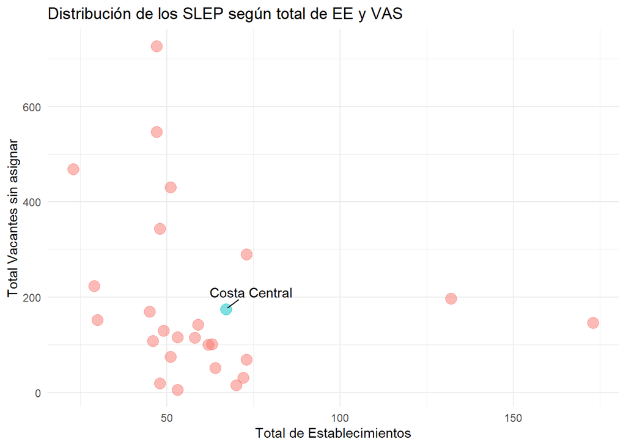

### 3.2.1 Comportamiento Histórico

En esta sección se presenta el comportamiento de las vacantes sin asignar (VAS) durante el periodo de Enero a Octubre 2025 para cada comuna del territorio.

**Antecedentes de fiscalización**

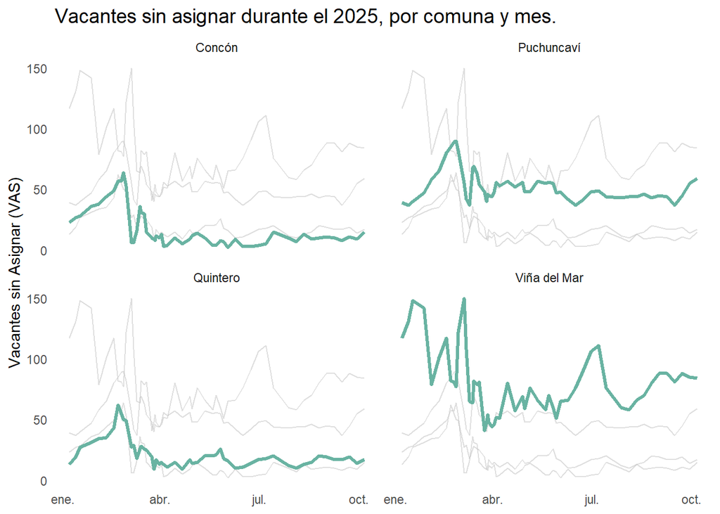

### 3.2.2 Variación vacantes sin Asignar

En esta sección se presenta el estado **actual** de las vacantes sin asignar por comuna.

| Comuna | lunes 06 octubre | lunes 29 septiembre | Variación entre mediciones |
| --- | --- | --- | --- |
| Puchuncaví | 59 | 55 | 4 |
| Viña del Mar | 84 | 85 | -1 |
| Quintero | 17 | 14 | 3 |
| Concón | 15 | 9 | 6 |

Fuente: Visor Anótate en la lista, 2025.

### 3.2.3 Listado de gestión.

En esta sección se presenta el listado de establecimientos más crítico en la asignación de vacantes disponibles.